# Data605-Week1-HomeWork1-kamath

Vinayak Kamath

8/30/2020

## Problem set 1

1. Calculate the dot product u:v where u = [0.5; 0.5] and v = [3;-4]

   ```r
   u <- matrix(c(0.5, 0.5), 1, 2)
   v <- matrix(c(3, -4), 1, 2)

   #print("dot product u:v is ")
   (0.5 *  3) + (0.5 * -4)
   ```

   ```
   ## [1] -0.5
   ```

2. What are the lengths of u and v? Please note that the mathematical notion of the length of a vector is not the same as a computer science defnition.

   ```r
   ulen <- sqrt(0.5**2 + 0.5**2)
   #print("lengths of u is ")
   ulen
   ```

   ```
   ## [1] 0.7071068
   ```

   ```r
   vlen <- sqrt(3**2 + (-4)**2 )
   #print("lengths of v is ")
   vlen
   ```

   ```
   ## [1] 5
   ```

3. What is the linear combination: 3u - 2v?

   ```r
   #print("linear combination: 3u - 2v is ")
   3*u - 2*v
   ```

   ```
   ##      [,1] [,2]
   ## [1,] -4.5  9.5
   ```

4. What is the angle between u and v

   ```r
   #print("angle between u and v is ")
   acos ( ( (0.5 *  3) + (0.5 * -4) )  / ( ulen  *  vlen  ) )
   ```

   ```
   ## [1] 1.712693
   ```

## Problem set 2

1. Set up a system of equations with 3 variables and 3 constraints and solve for x. Please write a function in R that will take two variables (matrix A & constraint vector b) and solve using elimination. Your function should produce the right answer for the system of equations for any 3-variable, 3-equation system. You don’t have to worry about degenerate cases and can safely assume that the function will only be tested with a system of equations that has a solution. Please note that you do have to worry about zero pivots, though. Please note that you should not use the built-in function solve to solve this system or use matrix inverses. The approach that you should employ is to construct an Upper Triangular Matrix and then back-substitute to get the solution. Alternatively, you can augment the matrix A with vector b and jointly apply the Gauss Jordan elimination procedure.Please test it with the system below and it should produce a solution x = [-1.55, -0.32, 0.95]

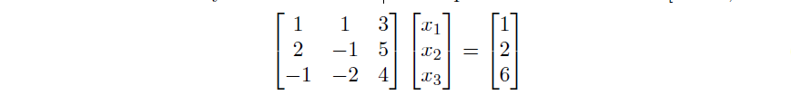

   ```r
   solve_x = function(A, b){
     r <- dim(A)[1]
     c <- dim(A)[2]+dim(b)[2]

     UT <- matrix(c(A, b), nrow=r, ncol=c)

     for (j in 1:(c-2)) {
       for (i in (j+1):r) {
         UT[i,] <- UT[i,]-UT[j,]*UT[i,j]/UT[j,j]
       }
     }

     UT[r,] <- UT[r,]/UT[r,r]
     xn <- numeric(r)
     xn[r] = UT[r,c]

     for (k in (r-1):1) {
       t = 0
       for (m in (k+1):r) {
         s = UT[k,m]*xn[m]
         t = t + s
       }
       xn[k] = (UT[k,c] - t) / UT[k,k]
     }

     x <- round(xn,2)

   return(x)

   }

   A <- matrix(c(1, 2, -1, 1, -1, -2, 3, 5, 4), nrow=3, ncol=3)
   b <- matrix(c(1, 2, 6), nrow=3, ncol=1)
   solve_x(A,b)
   ```

   ```
   ## [1] -1.55 -0.32  0.95
   ```